# Introduction to R

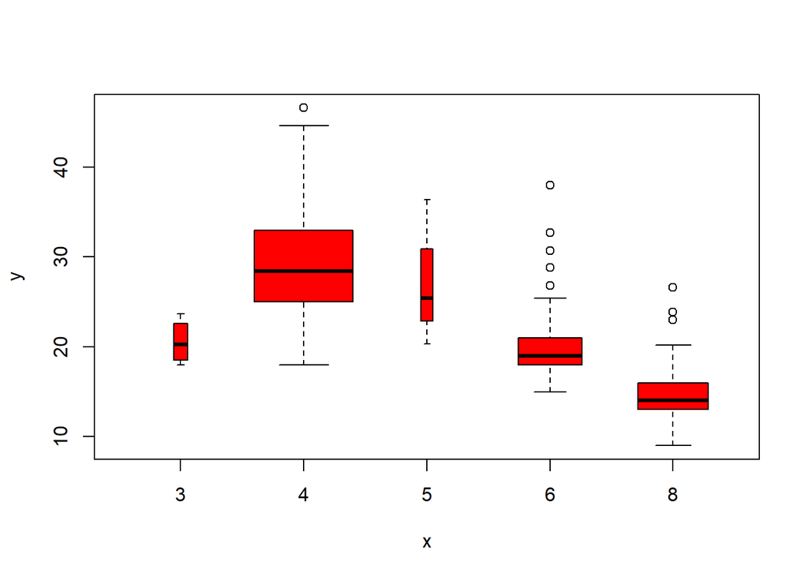

```r
plot(Auto$cylinders, Auto$mpg, col="red", varwidth=T)
```

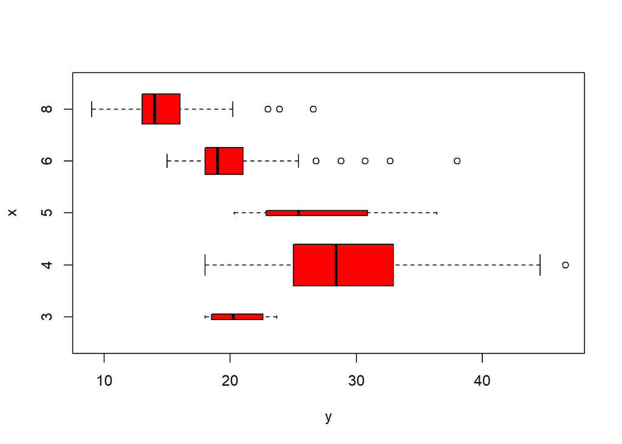

```r
plot(Auto$cylinders, Auto$mpg, col="red", varwidth=T,horizontal=T)
```

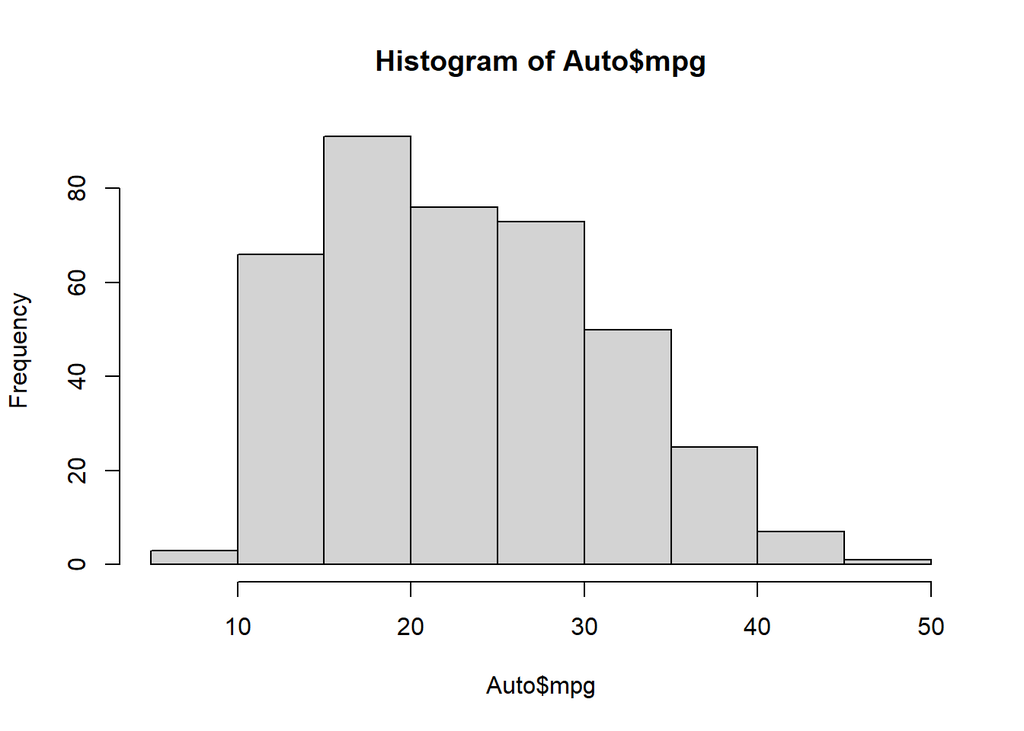

```r
hist(Auto$mpg)
```

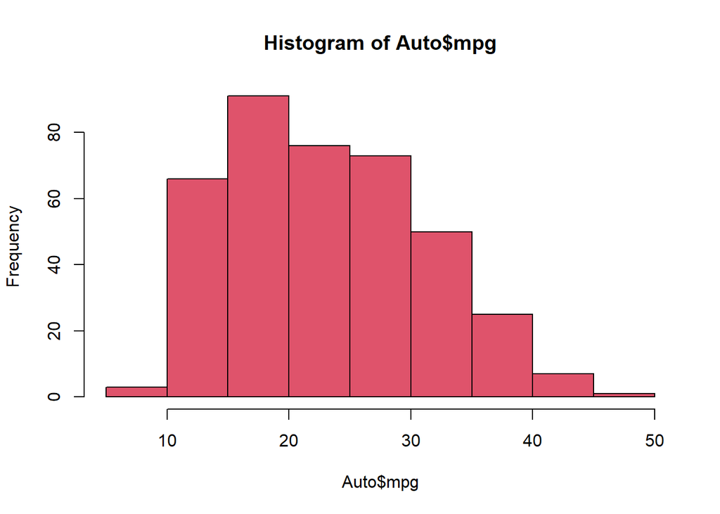

```r
hist(Auto$mpg,col=2)
```

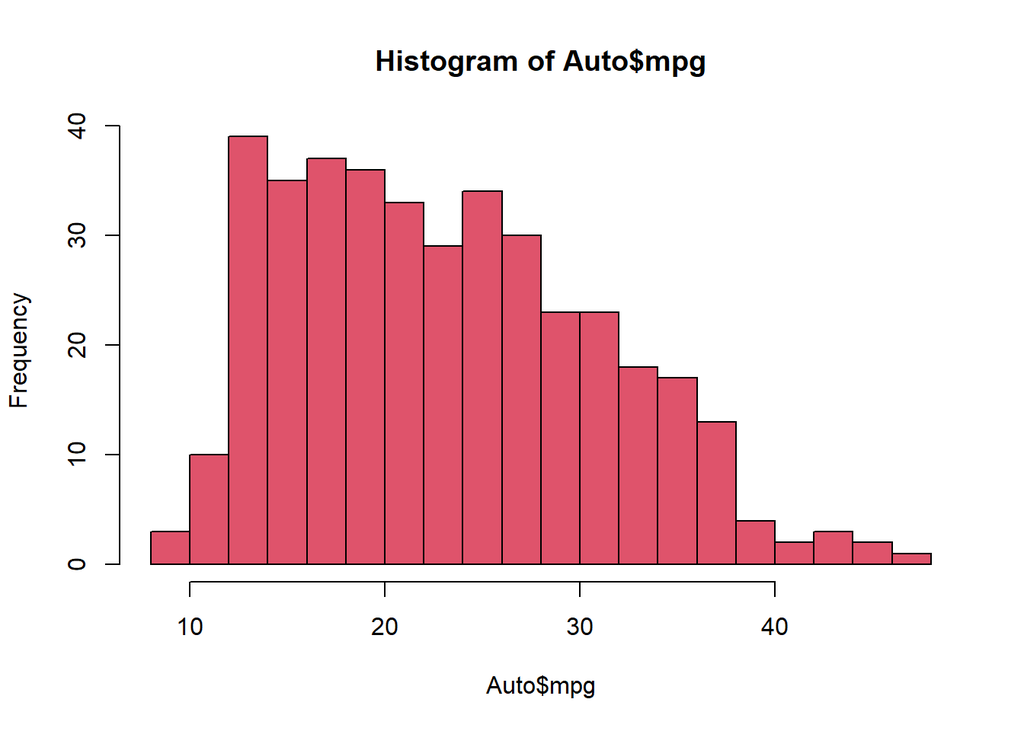

```r
hist(Auto$mpg,col=2,breaks=15)
```

The `pairs` function creates a scatterplot matrix, that is a scatterplot for every pair of variables for any given data set.

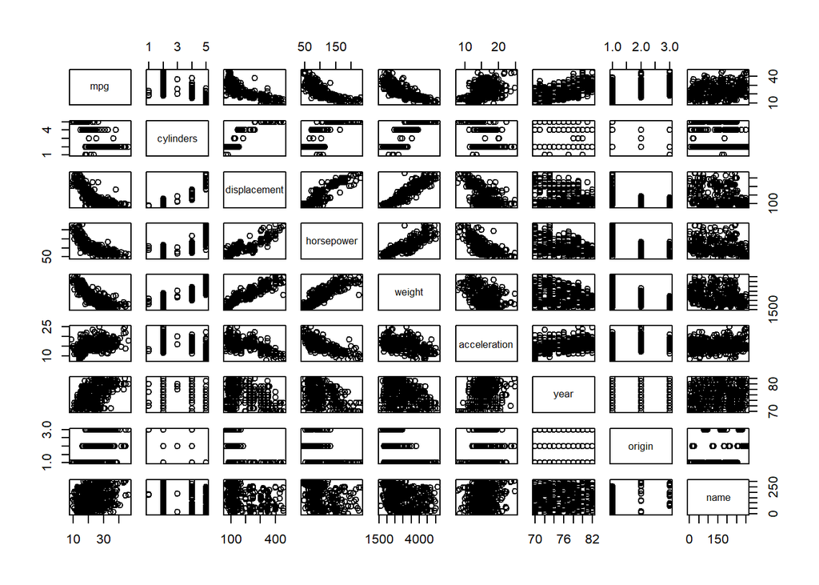

```r
pairs(Auto)
```

We can also produce scatterplots for just a subset of the variables.

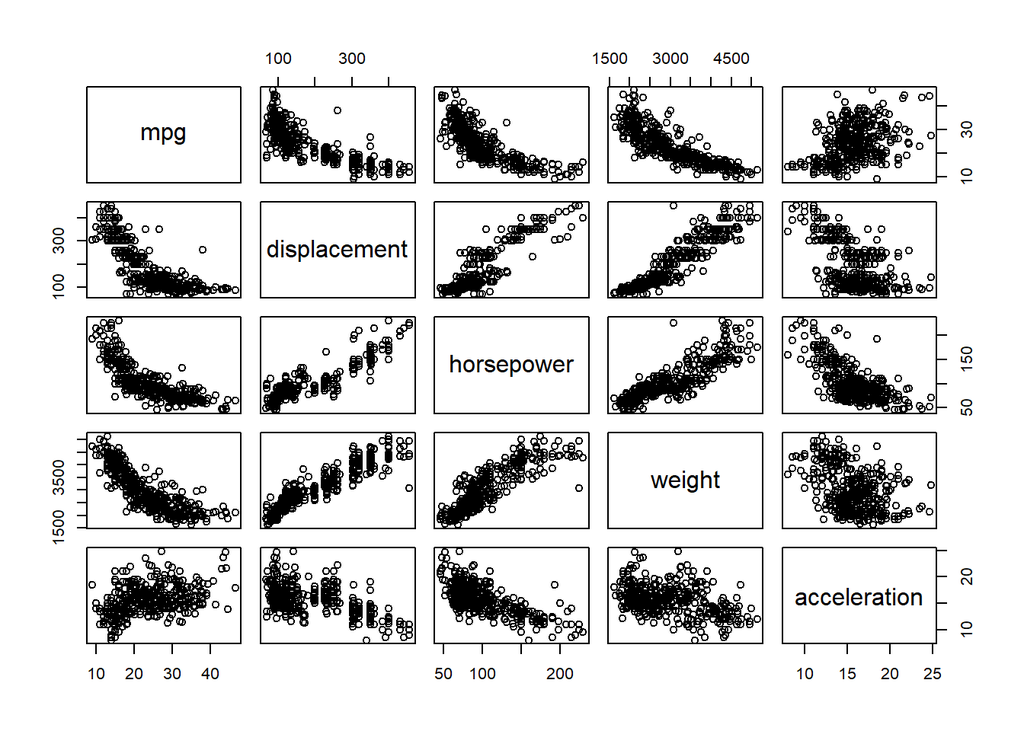

```r
pairs(~ mpg + displacement + horsepower + weight + acceleration, Auto)
```

In conjunction with the `plot` function, `identify` provides a useful interactive method for identifying the value for a particular variable for points on a plot. We pass in three arguments to `identify`:

- The x-axis variable
- The y-axis variable
- The variable whose values we would like to see printed

After we call identify we can click on the points we are interested on the displayed plot. Once we are finished selecting points, we end by pressing the escape key, and R then adds the annotated information onto the plot. In the console it also displays the row numbers of the selected data points.

An approach like this can be particularly useful to identify any outliers in the data

```r
plot(Auto$horsepower ,Auto$mpg)
identify(Auto$horsepower, Auto$mpg, Auto$name)
```

The `summary` function produces a numerical summary of each variable in a particular dataset:

```r
summary(Auto)
```

```
      mpg        cylinders  displacement     horsepower        weight
 Min.   : 9.00   3:  4     Min.   : 68.0   Min.   : 46.0   Min.   :1613
 1st Qu.:17.00   4:199     1st Qu.:105.0   1st Qu.: 75.0   1st Qu.:2225
 Median :22.75   5:  3     Median :151.0   Median : 93.5   Median :2804
 Mean   :23.45   6: 83     Mean   :194.4   Mean   :104.5   Mean   :2978
 3rd Qu.:29.00   8:103     3rd Qu.:275.8   3rd Qu.:126.0   3rd Qu.:3615
 Max.   :46.60             Max.   :455.0   Max.   :230.0   Max.   :5140

  acceleration        year           origin                      name
 Min.   : 8.00   Min.   :70.00   Min.   :1.000   amc matador       :  5
 1st Qu.:13.78   1st Qu.:73.00   1st Qu.:1.000   ford pinto        :  5
 Median :15.50   Median :76.00   Median :1.000   toyota corolla    :  5
 Mean   :15.54   Mean   :75.98   Mean   :1.577   amc gremlin       :  4
 3rd Qu.:17.02   3rd Qu.:79.00   3rd Qu.:2.000   amc hornet        :  4
 Max.   :24.80   Max.   :82.00   Max.   :3.000   chevrolet chevette:  4
                                                 (Other)           :365
```

We can also produce a summary of just a single column:

```r
summary(Auto$mpg)
```

```
   Min. 1st Qu.  Median    Mean 3rd Qu.    Max.
   9.00   17.00   22.75   23.45   29.00   46.60
```

For Factor variables such as name, R will list the number of observations that fall in each category.

## Exercises

### Analysis of the `Auto` dataset

**Exercises**

This involves the `Auto` dataset, imported via the `ISLR` package.

1. Which of the predictors are quantitative, and which are qualitative?
2. What is the range of each quantitative predictor?
3. What are the mean and standard deviation of each quantitative predictor?
4. Now remove the $10^{th}$ through $85^{th}$ observations. What are the range, mean, and standard deviation of each predictor in the subset of the data that remains?
5. Returning to the full dataset, investigate the predictors graphically, using scatterplots or other tools of your choice. Create some plots highlighting the relationships among the predictors. Comment on your findings.
6. Suppose that we wish to predict gas mileage, `mpg`, on the basis of the other variables. Do your plots suggest that any of the other variables might be useful in predicting `mpg`? Justify your answer.

### Analysis of the `Boston` dataset

This involves the `Boston` dataset, imported via the `MASS` package. The dataset that stores the characteristics of houses in the different suburbs (districts) around Boston in the USA.

**Exercises**

1. Load the `Boston` dataset from the `MASS` library and familiarise yourself with what the variables represent using the help file.
2. How many rows are in this data set? How many columns? What do the rows and columns represent?
3. Make some pairwise scatterplots of the predictors (columns) in this data set. Describe your findings.
4. Are any of the predictors associated with per capita crime rate? If so, explain the relationship.
5. Do any of the suburbs of Boston appear to have particularly high crime rates? Tax rates? Pupil-teacher ratios? Comment on the range of each predictor.
6. How many of the suburbs in this data set bound the Charles river?
7. What is the median pupil-teacher ratio among the towns in this data set?
8. Which suburb of Boston has lowest median value of owner occupied homes? What are the values of the other predictors for that suburb, and how do those values compare to the overall ranges for those predictors? Comment on your findings.
9. In this data set, how many of the suburbs average more than seven rooms per dwelling? More than eight rooms per dwelling? Comment on the characteristics of the suburbs that average more than eight rooms per dwelling.